# Risk Factor Analysis

## Outcome Variable

**Outcome Variable:** y_rate_wtkg

## Predictor Variables

**Intervention Variable:** safeh20

**Adjustment Set:**

- arm
- sex
- W_mage
- meducyrs
- feducyrs
- hhwealth_quart
- hfoodsec
- W_mhtcm
- W_mwtkg
- W_mbmi
- W_nrooms
- W_nchldlt5
- impfloor
- impsan
- delta_W_mage
- delta_meducyrs
- delta_feducyrs
- delta_hhwealth_quart
- delta_hfoodsec
- delta_W_mhtcm
- delta_W_mwtkg
- delta_W_mbmi
- delta_W_nrooms
- delta_W_nchldlt5
- delta_impfloor
- delta_impsan

## Stratifying Variables

The analysis was stratified on these variable(s):

- agecat
- studyid
- country

## Data Summary

| agecat | studyid | country | safeh20 | n_cell | n |
| --- | --- | --- | --- | --- | --- |
| 0-3 months | CONTENT | PERU | 1 | 5 | 6 |
| 0-3 months | CONTENT | PERU | 0 | 1 | 6 |
| 0-3 months | JiVitA-3 | BANGLADESH | 1 | 20238 | 20271 |
| 0-3 months | JiVitA-3 | BANGLADESH | 0 | 33 | 20271 |
| 0-3 months | JiVitA-4 | BANGLADESH | 1 | 1793 | 1793 |
| 0-3 months | JiVitA-4 | BANGLADESH | 0 | 0 | 1793 |
| 0-3 months | MAL-ED | BANGLADESH | 1 | 0 | 239 |
| 0-3 months | MAL-ED | BANGLADESH | 0 | 239 | 239 |
| 0-3 months | MAL-ED | BRAZIL | 1 | 0 | 142 |
| 0-3 months | MAL-ED | BRAZIL | 0 | 142 | 142 |
| 0-3 months | MAL-ED | INDIA | 1 | 0 | 232 |
| 0-3 months | MAL-ED | INDIA | 0 | 232 | 232 |
| 0-3 months | MAL-ED | NEPAL | 1 | 1 | 227 |
| 0-3 months | MAL-ED | NEPAL | 0 | 226 | 227 |
| 0-3 months | MAL-ED | PERU | 1 | 11 | 258 |
| 0-3 months | MAL-ED | PERU | 0 | 247 | 258 |
| 0-3 months | MAL-ED | SOUTH AFRICA | 1 | 38 | 251 |
| 0-3 months | MAL-ED | SOUTH AFRICA | 0 | 213 | 251 |
| 0-3 months | MAL-ED | TANZANIA, UNITED REPUBLIC OF | 1 | 158 | 232 |
| 0-3 months | MAL-ED | TANZANIA, UNITED REPUBLIC OF | 0 | 74 | 232 |
| 0-3 months | NIH-Birth | BANGLADESH | 1 | 563 | 565 |
| 0-3 months | NIH-Birth | BANGLADESH | 0 | 2 | 565 |
| 0-3 months | NIH-Crypto | BANGLADESH | 1 | 725 | 725 |
| 0-3 months | NIH-Crypto | BANGLADESH | 0 | 0 | 725 |
| 0-3 months | PROVIDE | BANGLADESH | 1 | 13 | 13 |
| 0-3 months | PROVIDE | BANGLADESH | 0 | 0 | 13 |
| 3-6 months | CONTENT | PERU | 1 | 54 | 57 |
| 3-6 months | CONTENT | PERU | 0 | 3 | 57 |
| 3-6 months | JiVitA-3 | BANGLADESH | 1 | 12701 | 12713 |
| 3-6 months | JiVitA-3 | BANGLADESH | 0 | 12 | 12713 |

[output cut: 182 more lines]

The following strata were considered:

- agecat: 0-3 months, studyid: CONTENT, country: PERU
- agecat: 0-3 months, studyid: JiVitA-3, country: BANGLADESH
- agecat: 0-3 months, studyid: JiVitA-4, country: BANGLADESH
- agecat: 0-3 months, studyid: MAL-ED, country: BANGLADESH
- agecat: 0-3 months, studyid: MAL-ED, country: BRAZIL
- agecat: 0-3 months, studyid: MAL-ED, country: INDIA
- agecat: 0-3 months, studyid: MAL-ED, country: NEPAL
- agecat: 0-3 months, studyid: MAL-ED, country: PERU
- agecat: 0-3 months, studyid: MAL-ED, country: SOUTH AFRICA
- agecat: 0-3 months, studyid: MAL-ED, country: TANZANIA, UNITED REPUBLIC OF
- agecat: 0-3 months, studyid: NIH-Birth, country: BANGLADESH
- agecat: 0-3 months, studyid: NIH-Crypto, country: BANGLADESH
- agecat: 0-3 months, studyid: PROVIDE, country: BANGLADESH
- agecat: 12-15 months, studyid: CONTENT, country: PERU
- agecat: 12-15 months, studyid: JiVitA-4, country: BANGLADESH
- agecat: 12-15 months, studyid: LCNI-5, country: MALAWI
- agecat: 12-15 months, studyid: MAL-ED, country: BANGLADESH
- agecat: 12-15 months, studyid: MAL-ED, country: BRAZIL
- agecat: 12-15 months, studyid: MAL-ED, country: INDIA
- agecat: 12-15 months, studyid: MAL-ED, country: NEPAL
- agecat: 12-15 months, studyid: MAL-ED, country: PERU
- agecat: 12-15 months, studyid: MAL-ED, country: SOUTH AFRICA
- agecat: 12-15 months, studyid: MAL-ED, country: TANZANIA, UNITED REPUBLIC OF
- agecat: 12-15 months, studyid: NIH-Birth, country: BANGLADESH
- agecat: 12-15 months, studyid: NIH-Crypto, country: BANGLADESH
- agecat: 12-15 months, studyid: PROVIDE, country: BANGLADESH
- agecat: 12-15 months, studyid: SAS-FoodSuppl, country: INDIA
- agecat: 15-18 months, studyid: CONTENT, country: PERU
- agecat: 15-18 months, studyid: JiVitA-4, country: BANGLADESH
- agecat: 15-18 months, studyid: LCNI-5, country: MALAWI
- agecat: 15-18 months, studyid: MAL-ED, country: BANGLADESH
- agecat: 15-18 months, studyid: MAL-ED, country: BRAZIL
- agecat: 15-18 months, studyid: MAL-ED, country: INDIA
- agecat: 15-18 months, studyid: MAL-ED, country: NEPAL
- agecat: 15-18 months, studyid: MAL-ED, country: PERU
- agecat: 15-18 months, studyid: MAL-ED, country: SOUTH AFRICA
- agecat: 15-18 months, studyid: MAL-ED, country: TANZANIA, UNITED REPUBLIC OF
- agecat: 15-18 months, studyid: NIH-Birth, country: BANGLADESH
- agecat: 15-18 months, studyid: NIH-Crypto, country: BANGLADESH
- agecat: 15-18 months, studyid: PROVIDE, country: BANGLADESH
- agecat: 15-18 months, studyid: SAS-FoodSuppl, country: INDIA
- agecat: 18-21 months, studyid: CONTENT, country: PERU
- agecat: 18-21 months, studyid: LCNI-5, country: MALAWI
- agecat: 18-21 months, studyid: MAL-ED, country: BANGLADESH
- agecat: 18-21 months, studyid: MAL-ED, country: BRAZIL
- agecat: 18-21 months, studyid: MAL-ED, country: INDIA
- agecat: 18-21 months, studyid: MAL-ED, country: NEPAL
- agecat: 18-21 months, studyid: MAL-ED, country: PERU
- agecat: 18-21 months, studyid: MAL-ED, country: SOUTH AFRICA
- agecat: 18-21 months, studyid: MAL-ED, country: TANZANIA, UNITED REPUBLIC OF
- agecat: 18-21 months, studyid: NIH-Birth, country: BANGLADESH
- agecat: 18-21 months, studyid: NIH-Crypto, country: BANGLADESH
- agecat: 18-21 months, studyid: PROVIDE, country: BANGLADESH
- agecat: 21-24 months, studyid: CONTENT, country: PERU
- agecat: 21-24 months, studyid: LCNI-5, country: MALAWI
- agecat: 21-24 months, studyid: MAL-ED, country: BANGLADESH
- agecat: 21-24 months, studyid: MAL-ED, country: BRAZIL
- agecat: 21-24 months, studyid: MAL-ED, country: INDIA
- agecat: 21-24 months, studyid: MAL-ED, country: NEPAL
- agecat: 21-24 months, studyid: MAL-ED, country: PERU
- agecat: 21-24 months, studyid: MAL-ED, country: SOUTH AFRICA
- agecat: 21-24 months, studyid: MAL-ED, country: TANZANIA, UNITED REPUBLIC OF
- agecat: 21-24 months, studyid: NIH-Birth, country: BANGLADESH
- agecat: 21-24 months, studyid: NIH-Crypto, country: BANGLADESH
- agecat: 21-24 months, studyid: PROVIDE, country: BANGLADESH
- agecat: 3-6 months, studyid: CONTENT, country: PERU
- agecat: 3-6 months, studyid: JiVitA-3, country: BANGLADESH
- agecat: 3-6 months, studyid: JiVitA-4, country: BANGLADESH
- agecat: 3-6 months, studyid: MAL-ED, country: BANGLADESH
- agecat: 3-6 months, studyid: MAL-ED, country: BRAZIL
- agecat: 3-6 months, studyid: MAL-ED, country: INDIA
- agecat: 3-6 months, studyid: MAL-ED, country: NEPAL
- agecat: 3-6 months, studyid: MAL-ED, country: PERU
- agecat: 3-6 months, studyid: MAL-ED, country: SOUTH AFRICA
- agecat: 3-6 months, studyid: MAL-ED, country: TANZANIA, UNITED REPUBLIC OF
- agecat: 3-6 months, studyid: NIH-Birth, country: BANGLADESH
- agecat: 3-6 months, studyid: NIH-Crypto, country: BANGLADESH
- agecat: 3-6 months, studyid: PROVIDE, country: BANGLADESH
- agecat: 6-9 months, studyid: CONTENT, country: PERU
- agecat: 6-9 months, studyid: JiVitA-4, country: BANGLADESH
- agecat: 6-9 months, studyid: LCNI-5, country: MALAWI
- agecat: 6-9 months, studyid: MAL-ED, country: BANGLADESH
- agecat: 6-9 months, studyid: MAL-ED, country: BRAZIL
- agecat: 6-9 months, studyid: MAL-ED, country: INDIA
- agecat: 6-9 months, studyid: MAL-ED, country: NEPAL
- agecat: 6-9 months, studyid: MAL-ED, country: PERU
- agecat: 6-9 months, studyid: MAL-ED, country: SOUTH AFRICA
- agecat: 6-9 months, studyid: MAL-ED, country: TANZANIA, UNITED REPUBLIC OF
- agecat: 6-9 months, studyid: NIH-Birth, country: BANGLADESH
- agecat: 6-9 months, studyid: NIH-Crypto, country: BANGLADESH
- agecat: 6-9 months, studyid: PROVIDE, country: BANGLADESH
- agecat: 6-9 months, studyid: SAS-FoodSuppl, country: INDIA
- agecat: 9-12 months, studyid: CONTENT, country: PERU
- agecat: 9-12 months, studyid: JiVitA-4, country: BANGLADESH
- agecat: 9-12 months, studyid: LCNI-5, country: MALAWI
- agecat: 9-12 months, studyid: MAL-ED, country: BANGLADESH
- agecat: 9-12 months, studyid: MAL-ED, country: BRAZIL
- agecat: 9-12 months, studyid: MAL-ED, country: INDIA
- agecat: 9-12 months, studyid: MAL-ED, country: NEPAL
- agecat: 9-12 months, studyid: MAL-ED, country: PERU
- agecat: 9-12 months, studyid: MAL-ED, country: SOUTH AFRICA
- agecat: 9-12 months, studyid: MAL-ED, country: TANZANIA, UNITED REPUBLIC OF
- agecat: 9-12 months, studyid: NIH-Birth, country: BANGLADESH
- agecat: 9-12 months, studyid: NIH-Crypto, country: BANGLADESH
- agecat: 9-12 months, studyid: PROVIDE, country: BANGLADESH
- agecat: 9-12 months, studyid: SAS-FoodSuppl, country: INDIA

### Dropped Strata

Some strata were dropped due to rare outcomes:

- agecat: 0-3 months, studyid: CONTENT, country: PERU
- agecat: 0-3 months, studyid: JiVitA-4, country: BANGLADESH
- agecat: 0-3 months, studyid: MAL-ED, country: BANGLADESH
- agecat: 0-3 months, studyid: MAL-ED, country: BRAZIL
- agecat: 0-3 months, studyid: MAL-ED, country: INDIA
- agecat: 0-3 months, studyid: MAL-ED, country: NEPAL
- agecat: 0-3 months, studyid: NIH-Birth, country: BANGLADESH
- agecat: 0-3 months, studyid: NIH-Crypto, country: BANGLADESH
- agecat: 0-3 months, studyid: PROVIDE, country: BANGLADESH
- agecat: 3-6 months, studyid: CONTENT, country: PERU
- agecat: 3-6 months, studyid: JiVitA-4, country: BANGLADESH
- agecat: 3-6 months, studyid: MAL-ED, country: BANGLADESH
- agecat: 3-6 months, studyid: MAL-ED, country: BRAZIL
- agecat: 3-6 months, studyid: MAL-ED, country: INDIA
- agecat: 3-6 months, studyid: MAL-ED, country: NEPAL
- agecat: 3-6 months, studyid: NIH-Birth, country: BANGLADESH
- agecat: 3-6 months, studyid: NIH-Crypto, country: BANGLADESH
- agecat: 3-6 months, studyid: PROVIDE, country: BANGLADESH
- agecat: 6-9 months, studyid: CONTENT, country: PERU
- agecat: 6-9 months, studyid: JiVitA-4, country: BANGLADESH
- agecat: 6-9 months, studyid: MAL-ED, country: BANGLADESH
- agecat: 6-9 months, studyid: MAL-ED, country: BRAZIL
- agecat: 6-9 months, studyid: MAL-ED, country: INDIA
- agecat: 6-9 months, studyid: MAL-ED, country: NEPAL
- agecat: 6-9 months, studyid: NIH-Birth, country: BANGLADESH
- agecat: 6-9 months, studyid: NIH-Crypto, country: BANGLADESH
- agecat: 6-9 months, studyid: PROVIDE, country: BANGLADESH
- agecat: 6-9 months, studyid: SAS-FoodSuppl, country: INDIA
- agecat: 9-12 months, studyid: CONTENT, country: PERU
- agecat: 9-12 months, studyid: JiVitA-4, country: BANGLADESH
- agecat: 9-12 months, studyid: MAL-ED, country: BANGLADESH
- agecat: 9-12 months, studyid: MAL-ED, country: BRAZIL
- agecat: 9-12 months, studyid: MAL-ED, country: INDIA
- agecat: 9-12 months, studyid: MAL-ED, country: NEPAL
- agecat: 9-12 months, studyid: NIH-Birth, country: BANGLADESH
- agecat: 9-12 months, studyid: NIH-Crypto, country: BANGLADESH
- agecat: 9-12 months, studyid: PROVIDE, country: BANGLADESH
- agecat: 9-12 months, studyid: SAS-FoodSuppl, country: INDIA
- agecat: 12-15 months, studyid: CONTENT, country: PERU
- agecat: 12-15 months, studyid: JiVitA-4, country: BANGLADESH
- agecat: 12-15 months, studyid: MAL-ED, country: BANGLADESH
- agecat: 12-15 months, studyid: MAL-ED, country: BRAZIL
- agecat: 12-15 months, studyid: MAL-ED, country: INDIA
- agecat: 12-15 months, studyid: MAL-ED, country: NEPAL
- agecat: 12-15 months, studyid: NIH-Birth, country: BANGLADESH
- agecat: 12-15 months, studyid: NIH-Crypto, country: BANGLADESH
- agecat: 12-15 months, studyid: PROVIDE, country: BANGLADESH
- agecat: 12-15 months, studyid: SAS-FoodSuppl, country: INDIA
- agecat: 15-18 months, studyid: CONTENT, country: PERU
- agecat: 15-18 months, studyid: JiVitA-4, country: BANGLADESH
- agecat: 15-18 months, studyid: MAL-ED, country: BANGLADESH
- agecat: 15-18 months, studyid: MAL-ED, country: BRAZIL
- agecat: 15-18 months, studyid: MAL-ED, country: INDIA
- agecat: 15-18 months, studyid: MAL-ED, country: NEPAL
- agecat: 15-18 months, studyid: NIH-Birth, country: BANGLADESH
- agecat: 15-18 months, studyid: NIH-Crypto, country: BANGLADESH
- agecat: 15-18 months, studyid: PROVIDE, country: BANGLADESH
- agecat: 15-18 months, studyid: SAS-FoodSuppl, country: INDIA
- agecat: 18-21 months, studyid: CONTENT, country: PERU
- agecat: 18-21 months, studyid: MAL-ED, country: BANGLADESH
- agecat: 18-21 months, studyid: MAL-ED, country: BRAZIL
- agecat: 18-21 months, studyid: MAL-ED, country: INDIA
- agecat: 18-21 months, studyid: MAL-ED, country: NEPAL
- agecat: 18-21 months, studyid: NIH-Birth, country: BANGLADESH
- agecat: 18-21 months, studyid: NIH-Crypto, country: BANGLADESH
- agecat: 18-21 months, studyid: PROVIDE, country: BANGLADESH
- agecat: 21-24 months, studyid: CONTENT, country: PERU
- agecat: 21-24 months, studyid: MAL-ED, country: BANGLADESH
- agecat: 21-24 months, studyid: MAL-ED, country: BRAZIL
- agecat: 21-24 months, studyid: MAL-ED, country: INDIA
- agecat: 21-24 months, studyid: MAL-ED, country: NEPAL
- agecat: 21-24 months, studyid: NIH-Birth, country: BANGLADESH
- agecat: 21-24 months, studyid: NIH-Crypto, country: BANGLADESH
- agecat: 21-24 months, studyid: PROVIDE, country: BANGLADESH

## Methods Detail

We’re interested in the causal parameters $E[Y_a]$ for all values of $a \in \mathcal{A}$. These parameters represent the mean outcome if, possibly contrary to fact, we intervened to set all units to have $A=a$. Under the randomization and positivity assumptions, these are identified by the statistical parameters $\psi_a=E_W[E_{Y|A,W}(Y|A=a,W)]$. In addition, we’re interested in the mean of $Y$, $E[Y]$ under no intervention (the observed mean). We will estimate these parameters by using SuperLearner to fit the relevant likelihood factors – $E_{Y|A,W}(Y|A=a,W)$ and $p(A=a|W)$, and then updating our likelihood fit using a joint TMLE.

For unadjusted analyses ($W=\{\}$), initial likelihoods were estimated using Lrnr_glm to estimate the simple $E(Y|A)$ and Lrnr_mean to estimate $p(A)$. For adjusted analyses, a small library containing Lrnr_glmnet, Lrnr_xgboost, and Lrnr_mean was used.

Having estimated these parameters, we will then use the delta method to estimate relative risks and attributable risks relative to a prespecified baseline level of $A$.

# Results Detail

## Results Plots

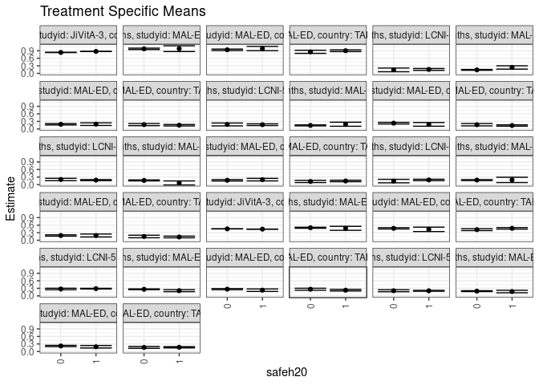

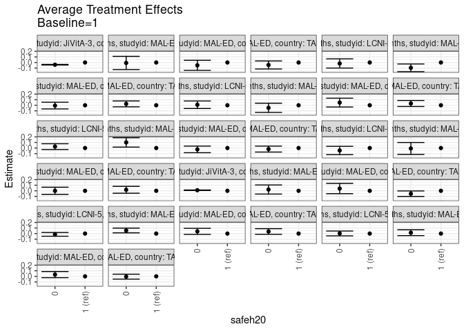

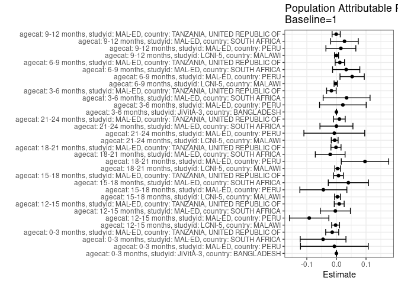

## Results Table

### Parameter: TSM

| agecat | studyid | country | intervention_level | baseline_level | estimate | ci_lower | ci_upper |
| --- | --- | --- | --- | --- | --- | --- | --- |
| 0-3 months | JiVitA-3 | BANGLADESH | 1 | NA | 0.8711242 | 0.8679701 | 0.8742783 |
| 0-3 months | JiVitA-3 | BANGLADESH | 0 | NA | 0.8307665 | 0.8265188 | 0.8350142 |
| 0-3 months | MAL-ED | PERU | 1 | NA | 0.9818306 | 0.8666402 | 1.0970211 |
| 0-3 months | MAL-ED | PERU | 0 | NA | 0.9741548 | 0.9467304 | 1.0015792 |
| 0-3 months | MAL-ED | SOUTH AFRICA | 1 | NA | 0.9866627 | 0.9014455 | 1.0718799 |
| 0-3 months | MAL-ED | SOUTH AFRICA | 0 | NA | 0.9361772 | 0.9066173 | 0.9657370 |
| 0-3 months | MAL-ED | TANZANIA, UNITED REPUBLIC OF | 1 | NA | 0.9004045 | 0.8647180 | 0.9360910 |
| 0-3 months | MAL-ED | TANZANIA, UNITED REPUBLIC OF | 0 | NA | 0.8560800 | 0.7939443 | 0.9182157 |
| 3-6 months | JiVitA-3 | BANGLADESH | 1 | NA | 0.4413843 | 0.4383462 | 0.4444224 |
| 3-6 months | JiVitA-3 | BANGLADESH | 0 | NA | 0.4518510 | 0.4490952 | 0.4546067 |
| 3-6 months | MAL-ED | PERU | 1 | NA | 0.4730516 | 0.3939259 | 0.5521774 |
| 3-6 months | MAL-ED | PERU | 0 | NA | 0.4961399 | 0.4760510 | 0.5162288 |
| 3-6 months | MAL-ED | SOUTH AFRICA | 1 | NA | 0.4324930 | 0.3446667 | 0.5203193 |
| 3-6 months | MAL-ED | SOUTH AFRICA | 0 | NA | 0.4732494 | 0.4462793 | 0.5002195 |
| 3-6 months | MAL-ED | TANZANIA, UNITED REPUBLIC OF | 1 | NA | 0.4736931 | 0.4431263 | 0.5042599 |
| 3-6 months | MAL-ED | TANZANIA, UNITED REPUBLIC OF | 0 | NA | 0.4216847 | 0.3830308 | 0.4603387 |
| 6-9 months | LCNI-5 | MALAWI | 1 | NA | 0.2872572 | 0.2733621 | 0.3011523 |
| 6-9 months | LCNI-5 | MALAWI | 0 | NA | 0.2733501 | 0.2430537 | 0.3036465 |
| 6-9 months | MAL-ED | PERU | 1 | NA | 0.2062279 | 0.1669678 | 0.2454881 |
| 6-9 months | MAL-ED | PERU | 0 | NA | 0.2616363 | 0.2453301 | 0.2779426 |
| 6-9 months | MAL-ED | SOUTH AFRICA | 1 | NA | 0.2266034 | 0.1776200 | 0.2755868 |
| 6-9 months | MAL-ED | SOUTH AFRICA | 0 | NA | 0.2664697 | 0.2431120 | 0.2898274 |
| 6-9 months | MAL-ED | TANZANIA, UNITED REPUBLIC OF | 1 | NA | 0.2262196 | 0.1952433 | 0.2571960 |
| 6-9 months | MAL-ED | TANZANIA, UNITED REPUBLIC OF | 0 | NA | 0.2638853 | 0.2243620 | 0.3034086 |
| 9-12 months | LCNI-5 | MALAWI | 1 | NA | 0.2019938 | 0.1844158 | 0.2195717 |
| 9-12 months | LCNI-5 | MALAWI | 0 | NA | 0.2043665 | 0.1648098 | 0.2439231 |
| 9-12 months | MAL-ED | PERU | 1 | NA | 0.1723232 | 0.1222520 | 0.2223945 |
| 9-12 months | MAL-ED | PERU | 0 | NA | 0.1879670 | 0.1717185 | 0.2042154 |
| 9-12 months | MAL-ED | SOUTH AFRICA | 1 | NA | 0.1881115 | 0.1392386 | 0.2369844 |
| 9-12 months | MAL-ED | SOUTH AFRICA | 0 | NA | 0.2199725 | 0.1950767 | 0.2448683 |
| 9-12 months | MAL-ED | TANZANIA, UNITED REPUBLIC OF | 1 | NA | 0.1679438 | 0.1434831 | 0.1924045 |
| 9-12 months | MAL-ED | TANZANIA, UNITED REPUBLIC OF | 0 | NA | 0.1622713 | 0.1257105 | 0.1988321 |
| 12-15 months | LCNI-5 | MALAWI | 1 | NA | 0.1546965 | 0.1168796 | 0.1925133 |
| 12-15 months | LCNI-5 | MALAWI | 0 | NA | 0.1372551 | 0.0640811 | 0.2104290 |
| 12-15 months | MAL-ED | PERU | 1 | NA | 0.2334736 | 0.1667517 | 0.3001954 |
| 12-15 months | MAL-ED | PERU | 0 | NA | 0.1379933 | 0.1206783 | 0.1553083 |
| 12-15 months | MAL-ED | SOUTH AFRICA | 1 | NA | 0.1916901 | 0.1388132 | 0.2445670 |
| 12-15 months | MAL-ED | SOUTH AFRICA | 0 | NA | 0.1861021 | 0.1576919 | 0.2145123 |
| 12-15 months | MAL-ED | TANZANIA, UNITED REPUBLIC OF | 1 | NA | 0.1497014 | 0.1194844 | 0.1799184 |
| 12-15 months | MAL-ED | TANZANIA, UNITED REPUBLIC OF | 0 | NA | 0.1743729 | 0.1317306 | 0.2170152 |
| 15-18 months | LCNI-5 | MALAWI | 1 | NA | 0.1703468 | 0.1351473 | 0.2055463 |
| 15-18 months | LCNI-5 | MALAWI | 0 | NA | 0.1797428 | 0.1222728 | 0.2372127 |
| 15-18 months | MAL-ED | PERU | 1 | NA | 0.1874214 | 0.1072172 | 0.2676256 |
| 15-18 months | MAL-ED | PERU | 0 | NA | 0.1415552 | 0.1218013 | 0.1613092 |
| 15-18 months | MAL-ED | SOUTH AFRICA | 1 | NA | 0.1823657 | 0.1094235 | 0.2553080 |
| 15-18 months | MAL-ED | SOUTH AFRICA | 0 | NA | 0.2304125 | 0.1991442 | 0.2616808 |
| 15-18 months | MAL-ED | TANZANIA, UNITED REPUBLIC OF | 1 | NA | 0.1379157 | 0.1124870 | 0.1633444 |
| 15-18 months | MAL-ED | TANZANIA, UNITED REPUBLIC OF | 0 | NA | 0.1695967 | 0.1217560 | 0.2174373 |
| 18-21 months | LCNI-5 | MALAWI | 1 | NA | 0.1778211 | 0.1553529 | 0.2002892 |
| 18-21 months | LCNI-5 | MALAWI | 0 | NA | 0.2031374 | 0.1564664 | 0.2498084 |
| 18-21 months | MAL-ED | PERU | 1 | NA | 0.0653975 | -0.0157629 | 0.1465580 |
| 18-21 months | MAL-ED | PERU | 0 | NA | 0.1660201 | 0.1463857 | 0.1856545 |
| 18-21 months | MAL-ED | SOUTH AFRICA | 1 | NA | 0.1965828 | 0.1461319 | 0.2470336 |
| 18-21 months | MAL-ED | SOUTH AFRICA | 0 | NA | 0.1718572 | 0.1417607 | 0.2019538 |
| 18-21 months | MAL-ED | TANZANIA, UNITED REPUBLIC OF | 1 | NA | 0.1449110 | 0.1152838 | 0.1745383 |
| 18-21 months | MAL-ED | TANZANIA, UNITED REPUBLIC OF | 0 | NA | 0.1259791 | 0.0821091 | 0.1698490 |
| 21-24 months | LCNI-5 | MALAWI | 1 | NA | 0.1848403 | 0.1555292 | 0.2141514 |
| 21-24 months | LCNI-5 | MALAWI | 0 | NA | 0.1408551 | 0.0720303 | 0.2096798 |
| 21-24 months | MAL-ED | PERU | 1 | NA | 0.1869388 | 0.0820127 | 0.2918650 |
| 21-24 months | MAL-ED | PERU | 0 | NA | 0.1795172 | 0.1591318 | 0.1999026 |
| 21-24 months | MAL-ED | SOUTH AFRICA | 1 | NA | 0.1878003 | 0.1286310 | 0.2469695 |
| 21-24 months | MAL-ED | SOUTH AFRICA | 0 | NA | 0.1878737 | 0.1616211 | 0.2141264 |
| 21-24 months | MAL-ED | TANZANIA, UNITED REPUBLIC OF | 1 | NA | 0.1301797 | 0.0965621 | 0.1637973 |
| 21-24 months | MAL-ED | TANZANIA, UNITED REPUBLIC OF | 0 | NA | 0.1486866 | 0.0974436 | 0.1999296 |

### Parameter: E(Y)

| agecat | studyid | country | intervention_level | baseline_level | estimate | ci_lower | ci_upper |
| --- | --- | --- | --- | --- | --- | --- | --- |
| 0-3 months | JiVitA-3 | BANGLADESH | NA | NA | 0.8710534 | 0.8679738 | 0.8741329 |
| 0-3 months | MAL-ED | PERU | NA | NA | 0.9748614 | 0.9482620 | 1.0014607 |
| 0-3 months | MAL-ED | SOUTH AFRICA | NA | NA | 0.9415988 | 0.9136365 | 0.9695612 |
| 0-3 months | MAL-ED | TANZANIA, UNITED REPUBLIC OF | NA | NA | 0.8861087 | 0.8555112 | 0.9167061 |
| 3-6 months | JiVitA-3 | BANGLADESH | NA | NA | 0.4413913 | 0.4384220 | 0.4443605 |
| 3-6 months | MAL-ED | PERU | NA | NA | 0.4948529 | 0.4753805 | 0.5143254 |
| 3-6 months | MAL-ED | SOUTH AFRICA | NA | NA | 0.4668837 | 0.4408277 | 0.4929397 |
| 3-6 months | MAL-ED | TANZANIA, UNITED REPUBLIC OF | NA | NA | 0.4566833 | 0.4325348 | 0.4808318 |
| 6-9 months | LCNI-5 | MALAWI | NA | NA | 0.2849079 | 0.2723110 | 0.2975048 |
| 6-9 months | MAL-ED | PERU | NA | NA | 0.2593318 | 0.2435782 | 0.2750853 |
| 6-9 months | MAL-ED | SOUTH AFRICA | NA | NA | 0.2596104 | 0.2384684 | 0.2807524 |
| 6-9 months | MAL-ED | TANZANIA, UNITED REPUBLIC OF | NA | NA | 0.2377801 | 0.2136152 | 0.2619451 |
| 9-12 months | LCNI-5 | MALAWI | NA | NA | 0.2022567 | 0.1863082 | 0.2182053 |
| 9-12 months | MAL-ED | PERU | NA | NA | 0.1873440 | 0.1716106 | 0.2030773 |
| 9-12 months | MAL-ED | SOUTH AFRICA | NA | NA | 0.2153147 | 0.1931793 | 0.2374501 |
| 9-12 months | MAL-ED | TANZANIA, UNITED REPUBLIC OF | NA | NA | 0.1670684 | 0.1467422 | 0.1873945 |
| 12-15 months | LCNI-5 | MALAWI | NA | NA | 0.1518822 | 0.1181702 | 0.1855942 |
| 12-15 months | MAL-ED | PERU | NA | NA | 0.1415461 | 0.1245184 | 0.1585737 |
| 12-15 months | MAL-ED | SOUTH AFRICA | NA | NA | 0.1879898 | 0.1627929 | 0.2131868 |
| 12-15 months | MAL-ED | TANZANIA, UNITED REPUBLIC OF | NA | NA | 0.1591083 | 0.1343053 | 0.1839113 |
| 15-18 months | LCNI-5 | MALAWI | NA | NA | 0.1738706 | 0.1423337 | 0.2054074 |
| 15-18 months | MAL-ED | PERU | NA | NA | 0.1433364 | 0.1240576 | 0.1626152 |
| 15-18 months | MAL-ED | SOUTH AFRICA | NA | NA | 0.2227120 | 0.1942678 | 0.2511562 |
| 15-18 months | MAL-ED | TANZANIA, UNITED REPUBLIC OF | NA | NA | 0.1449507 | 0.1222652 | 0.1676362 |
| 18-21 months | LCNI-5 | MALAWI | NA | NA | 0.1818489 | 0.1616805 | 0.2020172 |
| 18-21 months | MAL-ED | PERU | NA | NA | 0.1619131 | 0.1425878 | 0.1812383 |
| 18-21 months | MAL-ED | SOUTH AFRICA | NA | NA | 0.1755205 | 0.1490254 | 0.2020155 |
| 18-21 months | MAL-ED | TANZANIA, UNITED REPUBLIC OF | NA | NA | 0.1434559 | 0.1191029 | 0.1678089 |
| 21-24 months | LCNI-5 | MALAWI | NA | NA | 0.1789517 | 0.1520986 | 0.2058049 |
| 21-24 months | MAL-ED | PERU | NA | NA | 0.1798026 | 0.1597891 | 0.1998162 |
| 21-24 months | MAL-ED | SOUTH AFRICA | NA | NA | 0.1878453 | 0.1639966 | 0.2116939 |
| 21-24 months | MAL-ED | TANZANIA, UNITED REPUBLIC OF | NA | NA | 0.1402078 | 0.1124924 | 0.1679233 |

### Parameter: ATE

| agecat | studyid | country | intervention_level | baseline_level | estimate | ci_lower | ci_upper |
| --- | --- | --- | --- | --- | --- | --- | --- |
| 0-3 months | JiVitA-3 | BANGLADESH | 1 | 1 | 0.0000000 | 0.0000000 | 0.0000000 |
| 0-3 months | JiVitA-3 | BANGLADESH | 0 | 1 | -0.0403576 | -0.0455956 | -0.0351197 |
| 0-3 months | MAL-ED | PERU | 1 | 1 | 0.0000000 | 0.0000000 | 0.0000000 |
| 0-3 months | MAL-ED | PERU | 0 | 1 | -0.0076759 | -0.1261507 | 0.1107990 |
| 0-3 months | MAL-ED | SOUTH AFRICA | 1 | 1 | 0.0000000 | 0.0000000 | 0.0000000 |
| 0-3 months | MAL-ED | SOUTH AFRICA | 0 | 1 | -0.0504855 | -0.1407402 | 0.0397692 |
| 0-3 months | MAL-ED | TANZANIA, UNITED REPUBLIC OF | 1 | 1 | 0.0000000 | 0.0000000 | 0.0000000 |
| 0-3 months | MAL-ED | TANZANIA, UNITED REPUBLIC OF | 0 | 1 | -0.0443245 | -0.1160504 | 0.0274013 |
| 3-6 months | JiVitA-3 | BANGLADESH | 1 | 1 | 0.0000000 | 0.0000000 | 0.0000000 |
| 3-6 months | JiVitA-3 | BANGLADESH | 0 | 1 | 0.0104667 | 0.0065526 | 0.0143808 |
| 3-6 months | MAL-ED | PERU | 1 | 1 | 0.0000000 | 0.0000000 | 0.0000000 |
| 3-6 months | MAL-ED | PERU | 0 | 1 | 0.0230883 | -0.0587010 | 0.1048775 |
| 3-6 months | MAL-ED | SOUTH AFRICA | 1 | 1 | 0.0000000 | 0.0000000 | 0.0000000 |
| 3-6 months | MAL-ED | SOUTH AFRICA | 0 | 1 | 0.0407564 | -0.0514493 | 0.1329620 |
| 3-6 months | MAL-ED | TANZANIA, UNITED REPUBLIC OF | 1 | 1 | 0.0000000 | 0.0000000 | 0.0000000 |
| 3-6 months | MAL-ED | TANZANIA, UNITED REPUBLIC OF | 0 | 1 | -0.0520084 | -0.1016568 | -0.0023600 |
| 6-9 months | LCNI-5 | MALAWI | 1 | 1 | 0.0000000 | 0.0000000 | 0.0000000 |
| 6-9 months | LCNI-5 | MALAWI | 0 | 1 | -0.0139071 | -0.0472979 | 0.0194837 |
| 6-9 months | MAL-ED | PERU | 1 | 1 | 0.0000000 | 0.0000000 | 0.0000000 |
| 6-9 months | MAL-ED | PERU | 0 | 1 | 0.0554084 | 0.0129909 | 0.0978258 |
| 6-9 months | MAL-ED | SOUTH AFRICA | 1 | 1 | 0.0000000 | 0.0000000 | 0.0000000 |
| 6-9 months | MAL-ED | SOUTH AFRICA | 0 | 1 | 0.0398663 | -0.0144536 | 0.0941863 |
| 6-9 months | MAL-ED | TANZANIA, UNITED REPUBLIC OF | 1 | 1 | 0.0000000 | 0.0000000 | 0.0000000 |
| 6-9 months | MAL-ED | TANZANIA, UNITED REPUBLIC OF | 0 | 1 | 0.0376657 | -0.0127082 | 0.0880396 |
| 9-12 months | LCNI-5 | MALAWI | 1 | 1 | 0.0000000 | 0.0000000 | 0.0000000 |
| 9-12 months | LCNI-5 | MALAWI | 0 | 1 | 0.0023727 | -0.0409066 | 0.0456521 |
| 9-12 months | MAL-ED | PERU | 1 | 1 | 0.0000000 | 0.0000000 | 0.0000000 |
| 9-12 months | MAL-ED | PERU | 0 | 1 | 0.0156437 | -0.0369979 | 0.0682854 |
| 9-12 months | MAL-ED | SOUTH AFRICA | 1 | 1 | 0.0000000 | 0.0000000 | 0.0000000 |
| 9-12 months | MAL-ED | SOUTH AFRICA | 0 | 1 | 0.0318610 | -0.0230586 | 0.0867806 |
| 9-12 months | MAL-ED | TANZANIA, UNITED REPUBLIC OF | 1 | 1 | 0.0000000 | 0.0000000 | 0.0000000 |
| 9-12 months | MAL-ED | TANZANIA, UNITED REPUBLIC OF | 0 | 1 | -0.0056725 | -0.0496026 | 0.0382576 |
| 12-15 months | LCNI-5 | MALAWI | 1 | 1 | 0.0000000 | 0.0000000 | 0.0000000 |
| 12-15 months | LCNI-5 | MALAWI | 0 | 1 | -0.0174414 | -0.0996313 | 0.0647485 |
| 12-15 months | MAL-ED | PERU | 1 | 1 | 0.0000000 | 0.0000000 | 0.0000000 |
| 12-15 months | MAL-ED | PERU | 0 | 1 | -0.0954802 | -0.1644122 | -0.0265483 |
| 12-15 months | MAL-ED | SOUTH AFRICA | 1 | 1 | 0.0000000 | 0.0000000 | 0.0000000 |
| 12-15 months | MAL-ED | SOUTH AFRICA | 0 | 1 | -0.0055880 | -0.0658178 | 0.0546419 |
| 12-15 months | MAL-ED | TANZANIA, UNITED REPUBLIC OF | 1 | 1 | 0.0000000 | 0.0000000 | 0.0000000 |
| 12-15 months | MAL-ED | TANZANIA, UNITED REPUBLIC OF | 0 | 1 | 0.0246715 | -0.0278040 | 0.0771470 |
| 15-18 months | LCNI-5 | MALAWI | 1 | 1 | 0.0000000 | 0.0000000 | 0.0000000 |
| 15-18 months | LCNI-5 | MALAWI | 0 | 1 | 0.0093959 | -0.0578984 | 0.0766902 |
| 15-18 months | MAL-ED | PERU | 1 | 1 | 0.0000000 | 0.0000000 | 0.0000000 |
| 15-18 months | MAL-ED | PERU | 0 | 1 | -0.0458662 | -0.1284672 | 0.0367349 |
| 15-18 months | MAL-ED | SOUTH AFRICA | 1 | 1 | 0.0000000 | 0.0000000 | 0.0000000 |
| 15-18 months | MAL-ED | SOUTH AFRICA | 0 | 1 | 0.0480468 | -0.0310814 | 0.1271749 |
| 15-18 months | MAL-ED | TANZANIA, UNITED REPUBLIC OF | 1 | 1 | 0.0000000 | 0.0000000 | 0.0000000 |
| 15-18 months | MAL-ED | TANZANIA, UNITED REPUBLIC OF | 0 | 1 | 0.0316810 | -0.0222468 | 0.0856088 |
| 18-21 months | LCNI-5 | MALAWI | 1 | 1 | 0.0000000 | 0.0000000 | 0.0000000 |
| 18-21 months | LCNI-5 | MALAWI | 0 | 1 | 0.0253164 | -0.0266112 | 0.0772439 |
| 18-21 months | MAL-ED | PERU | 1 | 1 | 0.0000000 | 0.0000000 | 0.0000000 |
| 18-21 months | MAL-ED | PERU | 0 | 1 | 0.1006226 | 0.0171209 | 0.1841242 |
| 18-21 months | MAL-ED | SOUTH AFRICA | 1 | 1 | 0.0000000 | 0.0000000 | 0.0000000 |
| 18-21 months | MAL-ED | SOUTH AFRICA | 0 | 1 | -0.0247255 | -0.0835132 | 0.0340621 |
| 18-21 months | MAL-ED | TANZANIA, UNITED REPUBLIC OF | 1 | 1 | 0.0000000 | 0.0000000 | 0.0000000 |
| 18-21 months | MAL-ED | TANZANIA, UNITED REPUBLIC OF | 0 | 1 | -0.0189320 | -0.0721822 | 0.0343183 |
| 21-24 months | LCNI-5 | MALAWI | 1 | 1 | 0.0000000 | 0.0000000 | 0.0000000 |
| 21-24 months | LCNI-5 | MALAWI | 0 | 1 | -0.0439852 | -0.1188277 | 0.0308572 |
| 21-24 months | MAL-ED | PERU | 1 | 1 | 0.0000000 | 0.0000000 | 0.0000000 |
| 21-24 months | MAL-ED | PERU | 0 | 1 | -0.0074216 | -0.1143097 | 0.0994665 |
| 21-24 months | MAL-ED | SOUTH AFRICA | 1 | 1 | 0.0000000 | 0.0000000 | 0.0000000 |
| 21-24 months | MAL-ED | SOUTH AFRICA | 0 | 1 | 0.0000735 | -0.0645990 | 0.0647460 |
| 21-24 months | MAL-ED | TANZANIA, UNITED REPUBLIC OF | 1 | 1 | 0.0000000 | 0.0000000 | 0.0000000 |
| 21-24 months | MAL-ED | TANZANIA, UNITED REPUBLIC OF | 0 | 1 | 0.0185070 | -0.0432369 | 0.0802508 |

### Parameter: PAR

| agecat | studyid | country | intervention_level | baseline_level | estimate | ci_lower | ci_upper |
| --- | --- | --- | --- | --- | --- | --- | --- |
| 0-3 months | JiVitA-3 | BANGLADESH | 1 | NA | -0.0000708 | -0.0002032 | 0.0000617 |
| 0-3 months | MAL-ED | PERU | 1 | NA | -0.0069693 | -0.1214282 | 0.1074896 |
| 0-3 months | MAL-ED | SOUTH AFRICA | 1 | NA | -0.0450638 | -0.1223086 | 0.0321809 |
| 0-3 months | MAL-ED | TANZANIA, UNITED REPUBLIC OF | 1 | NA | -0.0142959 | -0.0363149 | 0.0077232 |
| 3-6 months | JiVitA-3 | BANGLADESH | 1 | NA | 0.0000070 | -0.0000915 | 0.0001056 |
| 3-6 months | MAL-ED | PERU | 1 | NA | 0.0218013 | -0.0570042 | 0.1006068 |
| 3-6 months | MAL-ED | SOUTH AFRICA | 1 | NA | 0.0343907 | -0.0448705 | 0.1136519 |
| 3-6 months | MAL-ED | TANZANIA, UNITED REPUBLIC OF | 1 | NA | -0.0170098 | -0.0331642 | -0.0008554 |
| 6-9 months | LCNI-5 | MALAWI | 1 | NA | -0.0023493 | -0.0079420 | 0.0032434 |
| 6-9 months | MAL-ED | PERU | 1 | NA | 0.0531038 | 0.0120695 | 0.0941381 |
| 6-9 months | MAL-ED | SOUTH AFRICA | 1 | NA | 0.0330070 | -0.0130272 | 0.0790412 |
| 6-9 months | MAL-ED | TANZANIA, UNITED REPUBLIC OF | 1 | NA | 0.0115605 | -0.0042452 | 0.0273662 |
| 9-12 months | LCNI-5 | MALAWI | 1 | NA | 0.0002630 | -0.0066586 | 0.0071845 |
| 9-12 months | MAL-ED | PERU | 1 | NA | 0.0150207 | -0.0355261 | 0.0655676 |
| 9-12 months | MAL-ED | SOUTH AFRICA | 1 | NA | 0.0272031 | -0.0194450 | 0.0738513 |
| 9-12 months | MAL-ED | TANZANIA, UNITED REPUBLIC OF | 1 | NA | -0.0008755 | -0.0146720 | 0.0129211 |
| 12-15 months | LCNI-5 | MALAWI | 1 | NA | -0.0028143 | -0.0161781 | 0.0105496 |
| 12-15 months | MAL-ED | PERU | 1 | NA | -0.0919275 | -0.1583387 | -0.0255163 |
| 12-15 months | MAL-ED | SOUTH AFRICA | 1 | NA | -0.0037003 | -0.0546347 | 0.0472342 |
| 12-15 months | MAL-ED | TANZANIA, UNITED REPUBLIC OF | 1 | NA | 0.0094069 | -0.0073626 | 0.0261763 |
| 15-18 months | LCNI-5 | MALAWI | 1 | NA | 0.0035237 | -0.0062777 | 0.0133252 |
| 15-18 months | MAL-ED | PERU | 1 | NA | -0.0440850 | -0.1234875 | 0.0353175 |
| 15-18 months | MAL-ED | SOUTH AFRICA | 1 | NA | 0.0403463 | -0.0275490 | 0.1082415 |
| 15-18 months | MAL-ED | TANZANIA, UNITED REPUBLIC OF | 1 | NA | 0.0070350 | -0.0094420 | 0.0235121 |
| 18-21 months | LCNI-5 | MALAWI | 1 | NA | 0.0040278 | -0.0054763 | 0.0135319 |
| 18-21 months | MAL-ED | PERU | 1 | NA | 0.0965155 | 0.0163734 | 0.1766577 |
| 18-21 months | MAL-ED | SOUTH AFRICA | 1 | NA | -0.0210623 | -0.0713656 | 0.0292410 |
| 18-21 months | MAL-ED | TANZANIA, UNITED REPUBLIC OF | 1 | NA | -0.0014551 | -0.0184924 | 0.0155822 |
| 21-24 months | LCNI-5 | MALAWI | 1 | NA | -0.0058885 | -0.0174595 | 0.0056824 |
| 21-24 months | MAL-ED | PERU | 1 | NA | -0.0071362 | -0.1099134 | 0.0956410 |
| 21-24 months | MAL-ED | SOUTH AFRICA | 1 | NA | 0.0000450 | -0.0556817 | 0.0557717 |
| 21-24 months | MAL-ED | TANZANIA, UNITED REPUBLIC OF | 1 | NA | 0.0100281 | -0.0096617 | 0.0297180 |